# Cruisin’ for a Conclusion: Insights into SFPD Traffic Stops

Justin Ong

2023-12-10

# Research Questions

1. Is there racial disparity in traffic stops conducted by San Francisco Police Department?
2. Are traffic stop rates for non-white drivers different under different district attorneys?

# Background

1. Police stops in the US suffer from persistent racial bias, particularly against black drivers.
2. Racially disproportionate traffic stops are often enabled and exasperated by legal doctrines that enable racial profiling.

# Data

1. SFPD Traffic Stops: [The Stanford Open Policing Project](https://openpolicing.stanford.edu/data/)
2. San Francisco resident population: [FRED](https://fred.stlouisfed.org/series/CASANF0POP)
3. SFPD staffing: [Department of Justice](https://openjustice.doj.ca.gov/data)
4. Sunrise and Sunset data: [sunrise.maplogs](https://sunrise.maplogs.com/san_francisco_bay_area_ca_usa.2754.html?year=2016)
5. Shapefiles for SF neighborhoods: [DataSF](https://data.sfgov.org/Geographic-Locations-and-Boundaries/SF-Find-Neighborhoods/pty2-tcw4)

Dataset contains 905,257 rows, 51 columns.

```r
head(traffic_stops)
```

```
## # A tibble: 6 × 51
##   date       time    hour day_of_week month year_month  year subject_age
##   <date>     <time> <int> <fct>       <fct> <date>     <dbl>       <dbl>
## 1 2014-08-01 01'00"     0 Fri         Aug   2014-08-01  2014          NA
## 2 2014-08-01 01'00"     0 Fri         Aug   2014-08-01  2014          NA
## 3 2014-08-01 15'00"     0 Fri         Aug   2014-08-01  2014          NA
## 4 2014-08-01 18'00"     0 Fri         Aug   2014-08-01  2014          NA
## 5 2014-08-01 19'00"     0 Fri         Aug   2014-08-01  2014          NA
## 6 2014-08-01 30'00"     0 Fri         Aug   2014-08-01  2014          NA
## # ℹ 43 more variables: subject_race <fct>, subject_sex <fct>, outcome <fct>,
## #   search_conducted <lgl>, reason_for_stop <fct>, city_population <dbl>,
## #   officers <dbl>, sunrise <time>, sunset <time>, mayor <fct>,
## #   district_attorney <fct>, police_chief <fct>, officers_per_capita <dbl>,
## #   daylight_or_nighttime <fct>, geometry <POINT [°]>, longitude <dbl>,
## #   latitude <dbl>, location <chr>, neighborhood <fct>, other <int>,
## #   aapi <int>, hispanic <int>, black <int>, white <int>, female <int>, …
```

```r
head(long_district_attorneys)
```

```
## # A tibble: 6 × 5
##   neighborhood district_attorney da_avg_stops longitude latitude
##   <fct>        <chr>                    <dbl>     <dbl>    <dbl>
## 1 Alamo Square kamala_stops               296     -122.     37.8
## 2 Alamo Square gascon_stops               168     -122.     37.8
## 3 Anza Vista   kamala_stops                65     -122.     37.8
## 4 Anza Vista   gascon_stops                67     -122.     37.8
## 5 Apparel City kamala_stops               169     -122.     37.7
## 6 Apparel City gascon_stops               276     -122.     37.7
```

# Veil of Darkness

What is the veil of darkness test?

- We compare the racial composition of stopped drivers between daylight and nighttime.
- As it is more difficult to determine a driver’s race when it is dark, if bias exists towards a racial group, then we would expect their proportion of traffic stops to be smaller after sunset.
- Throughout the US, black drivers comprise a smaller proportion of drivers stopped after sunset, which suggests rampant discrimination.
- Interestingly, black drivers comprise a larger proportion after sunset in San Francisco.
- This might suggest racial impartiality, except for the disproportionality when compared to the city’s demographics.

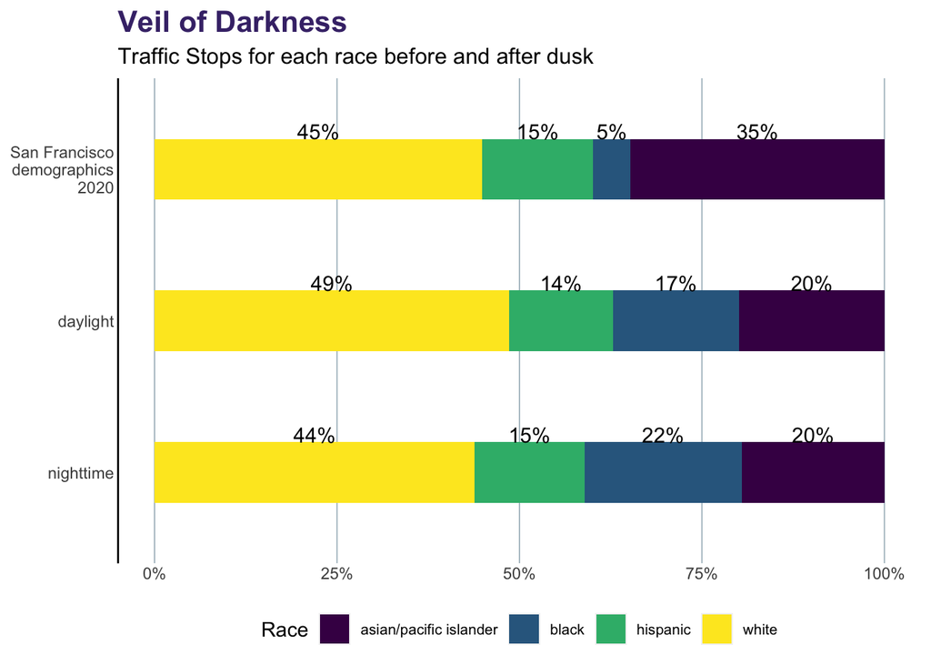

```
##
## Call:
## lm(formula = black_drivers ~ night_stops, data = traffic_stops_daily)
##
## Residuals:
##     Min      1Q  Median      3Q     Max
## -29.661  -8.055  -1.102   7.085  65.203
##
## Coefficients:
##              Estimate Std. Error t value Pr(>|t|)
## (Intercept) 23.627600   0.618053   38.23   <2e-16 ***
## night_stops  0.186438   0.005381   34.65   <2e-16 ***
## ---
## Signif. codes:  0 '***' 0.001 '**' 0.01 '*' 0.05 '.' 0.1 ' ' 1
##
## Residual standard error: 11.77 on 3466 degrees of freedom
## Multiple R-squared:  0.2572, Adjusted R-squared:  0.257
## F-statistic:  1200 on 1 and 3466 DF,  p-value: < 2.2e-16
```

# Kamala vs Gascon

- Outside of personal prejudicies, racial disparities in traffic stops can also be enabled and exasperated by laws that enable them.
- In 2012, the State of Washington court eased restriction on pretextual stops in *State v. Arreola*, which was associated with a statistically significant increase in traffic stops of drivers of color relative to white drivers.
- Further, this increase in traffic stops of drivers of color most occurred during daytime, when the race of drivers can be more easily ascertained.
- As a substitute, I try to assess if a change in District Attorney affects traffic stop rates in a statistically significant way, as DAs have strong influence on policing behaviors.

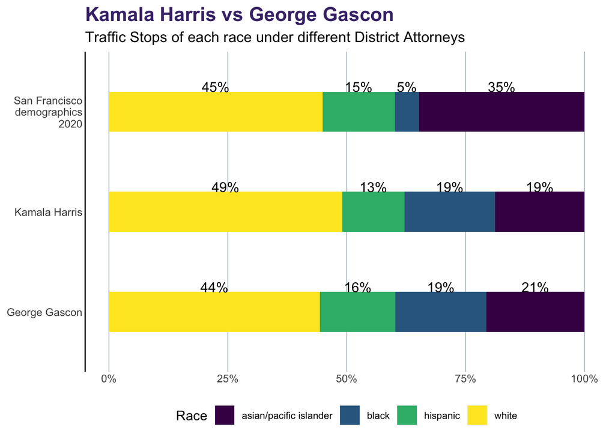

Regression Model: $NonWhite Drivers = \beta_0 + \beta_1{Kamala} + \beta_2{OfficersPerCapita} + \beta_3{Night} + \beta_4{Sex} + \epsilon$

```
##
## Call:
## lm(formula = non_white ~ kamala + officers_per_capita + nighttime +
##     subject_sex, data = traffic_stops)
##
## Residuals:
##     Min      1Q  Median      3Q     Max
## -0.6766 -0.5699  0.3489  0.4090  0.5164
##
## Coefficients:
##                      Estimate Std. Error t value Pr(>|t|)
## (Intercept)          1.095480   0.021706  50.470   <2e-16 ***
## kamala               0.004249   0.002465   1.724   0.0847 .
## officers_per_capita -0.148553   0.005844 -25.419   <2e-16 ***
## nighttime            0.041689   0.001047  39.816   <2e-16 ***
## subject_sexmale      0.072645   0.001133  64.135   <2e-16 ***
## ---
## Signif. codes:  0 '***' 0.001 '**' 0.01 '*' 0.05 '.' 0.1 ' ' 1
##
## Residual standard error: 0.4895 on 904768 degrees of freedom
##   (484 observations deleted due to missingness)
## Multiple R-squared:  0.01057,    Adjusted R-squared:  0.01056
## F-statistic:  2415 on 4 and 904768 DF,  p-value: < 2.2e-16
```

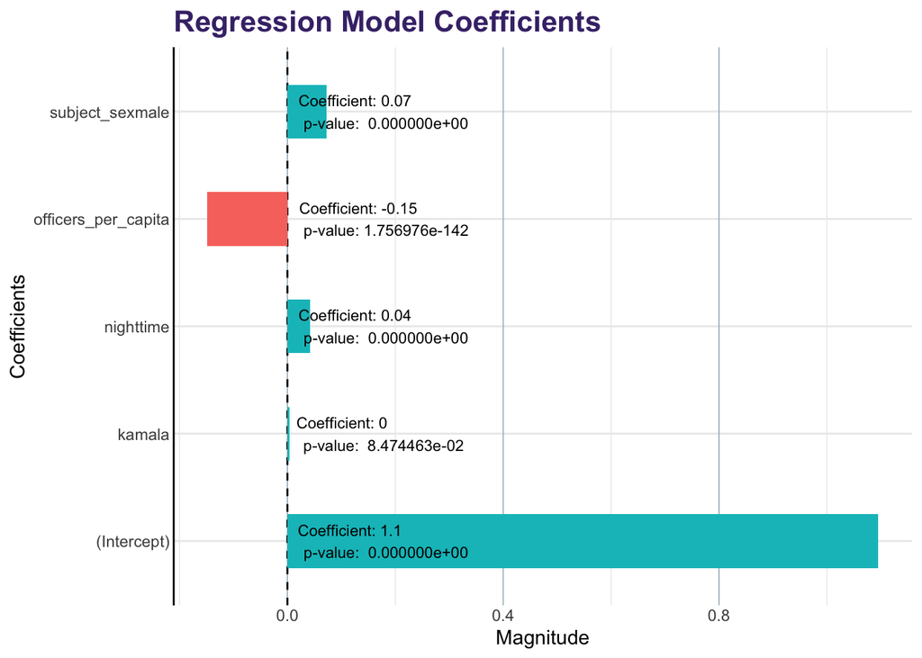

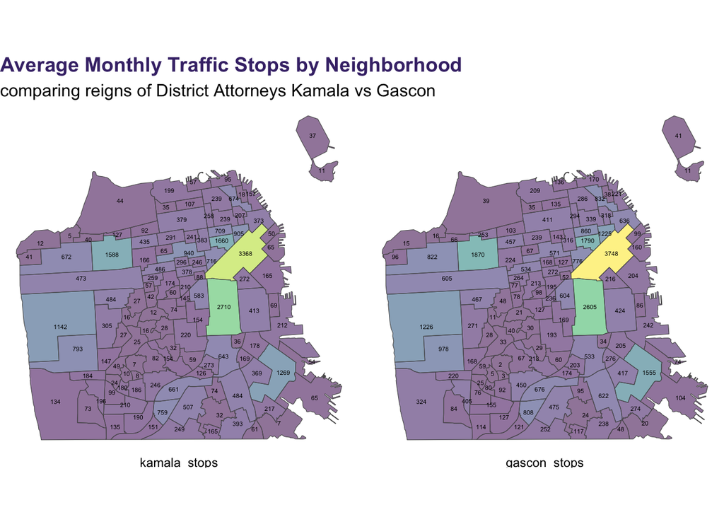

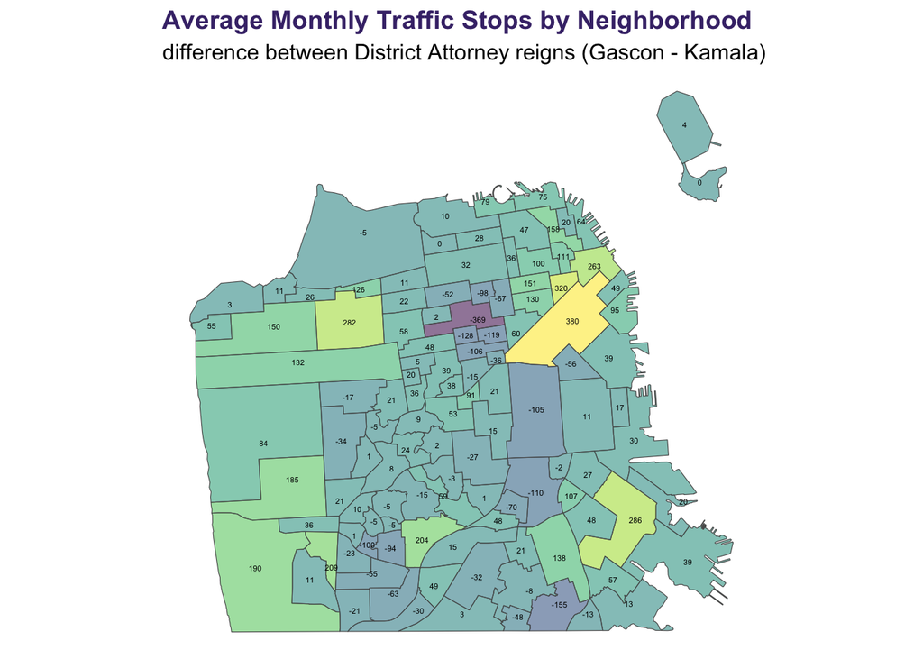

# Exploratory Analysis

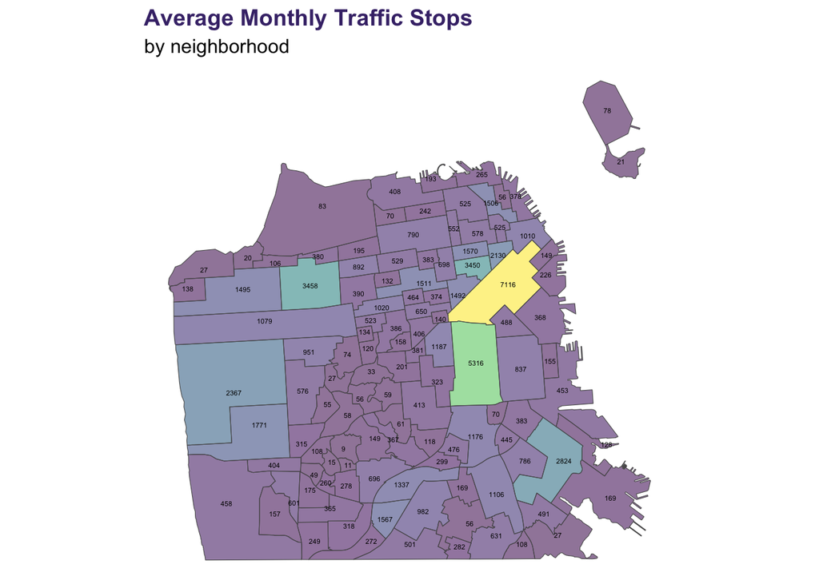

```
## # A tibble: 118 × 2
##    neighborhood            avg_stops
##    <fct>                       <dbl>
##  1 South of Market              7116
##  2 Mission                      5316
##  3 Inner Richmond               3458
##  4 Tenderloin                   3450
##  5 Bayview                      2824
##  6 Outer Sunset                 2367
##  7 Downtown / Union Square      2130
##  8 Parkside                     1771
##  9 Lower Nob Hill               1570
## 10 Cayuga                       1567
## # ℹ 108 more rows
```

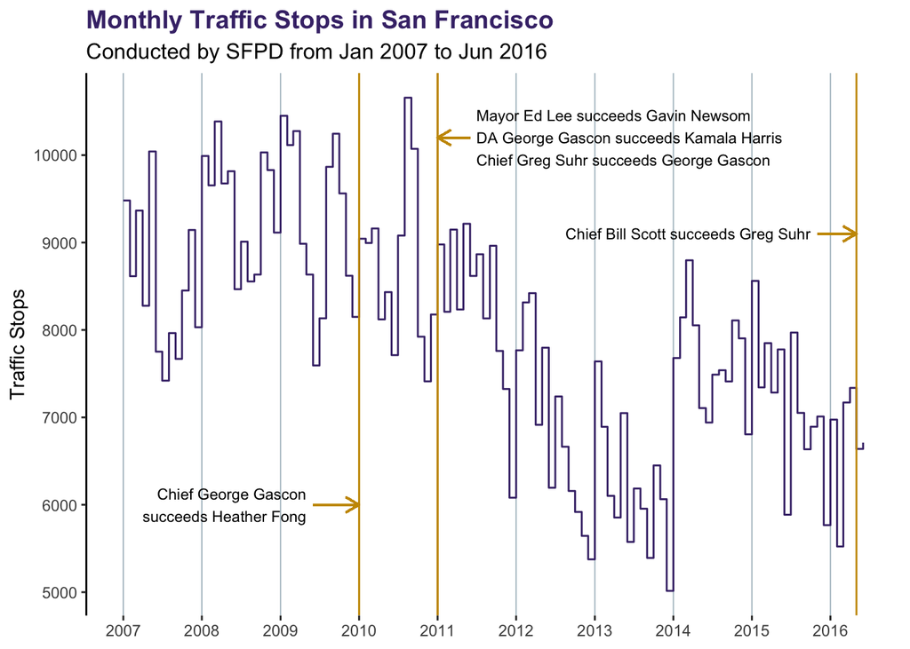

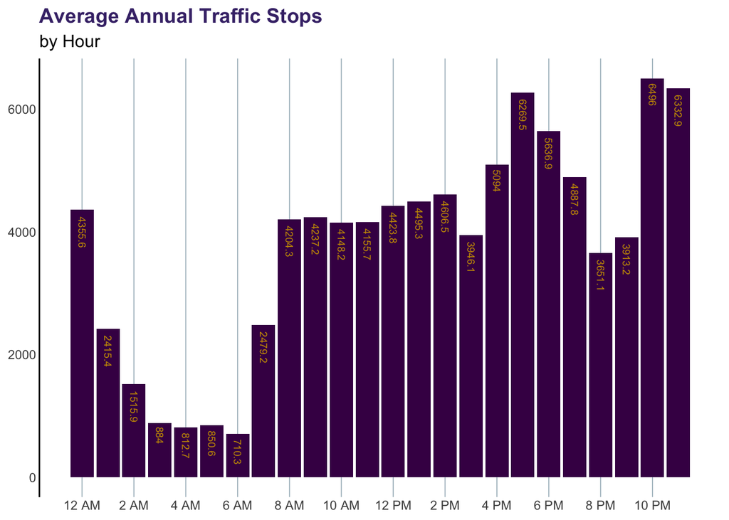

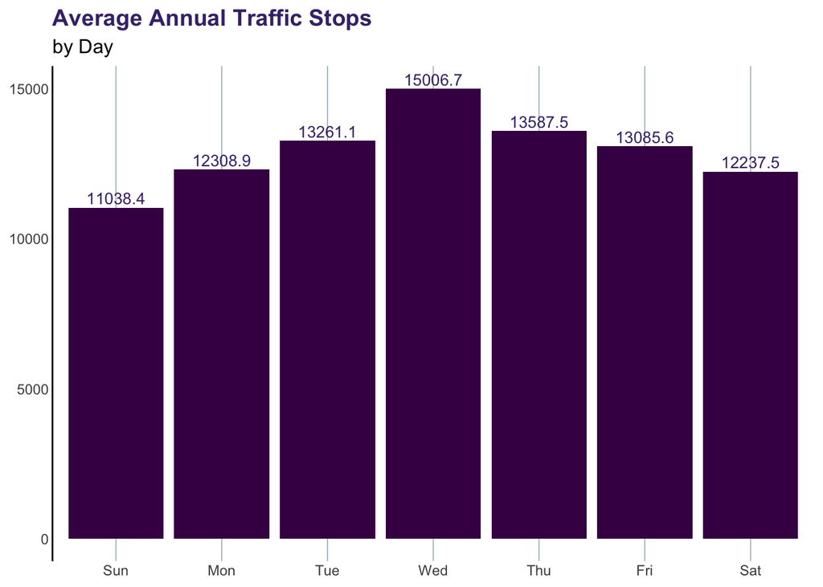

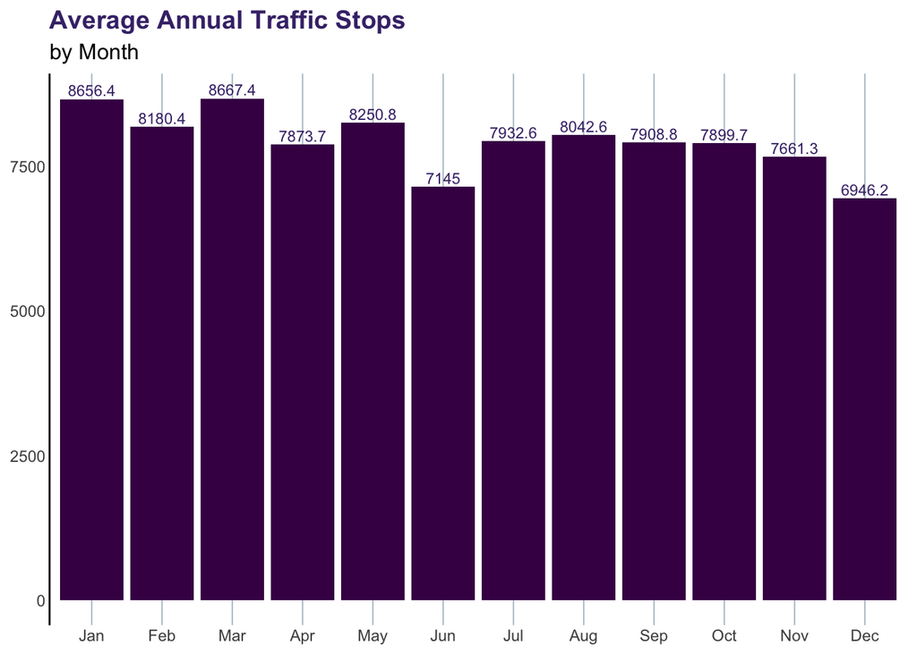

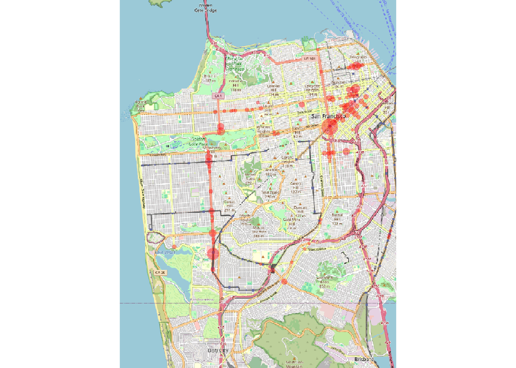

```
## # A tibble: 100 × 3
##    location                 neighborhood            count
##    <chr>                    <fct>                   <int>
##  1 NOE&29TH                 South of Market          4272
##  2 19TH AVE/WINSTON         Stonestown               3101
##  3 6TH ST/MARKET ST         Tenderloin               2648
##  4 STOCKTON/SUTTER          Downtown / Union Square  2271
##  5 COLUMBUS AND BROADWAY    North Beach              2222
##  6 FULTON ST. & FUNSTON AV. Inner Richmond           2105
##  7 19TH & SLOAT             Parkside                 1996
##  8 19TH & JUDAH             Outer Sunset             1947
##  9 MISSION & 16TH ST        Mission                  1889
## 10 6TH/MISSION              South of Market          1886
## # ℹ 90 more rows
```

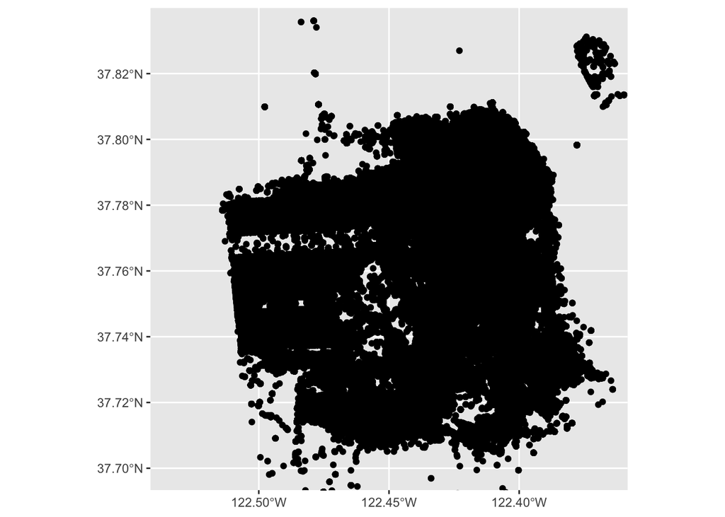

# Citations

1. Pierson, E. et al. (2020) ‘A Large-Scale Analysis of Racial Disparities in Police Stops Across the United States’, Nature Human Behaviour, 4(7), pp. 736–745. [doi:10.1038/s41562-020-0858-1](https://openpolicing.stanford.edu/publications/).
2. Rushin, S. and Edwards, G.S. (2019) ‘An Empirical Assessment of Pretextual Stops and Racial Profiling’, SSRN Electronic Journal [Preprint]. [doi:10.2139/ssrn.3506876](https://www.stanfordlawreview.org/print/article/an-empirical-assessment-of-pretextual-stops-and-racial-profiling/).